# Ventas de Apple entre 2008 y 2017

Marta Ruedas Burgos

11/16/2020

# Descripción de la tarea

Una vez seleccionado el modelo se estimara el modelo con todos los datos y se harán las predicciones del año 2017 y 2018.

# Objetivo

El objetivo es predecir las ventas de Apple. Los datos han sido obtenidos desde el 2T de 2008 hasta el 3T del 2017. La base de datos a importar es la siguiente: IngresosApple.csv.

# Librerías

Importación de librerías necesarias para el caso práctico.

```r
library(readr) # Read
library(skimr) # Pretty Summarizes
library(forecast)
library(xts)
library(ggplot2)
library(ggfortify) #Plot Monthplot
```

# Read Data

```
##    Trimestre Ingresos
## 1    Q2 2008     7980
## 2    Q3 2008     7561
## 3    Q4 2008    11520
## 4    Q1 2009    11880
## 5    Q2 2009     9084
## 6    Q3 2009     9734
## 7    Q4 2009    12207
## 8    Q1 2010    15683
## 9    Q2 2010    13499
## 10   Q3 2010    15700
## 11   Q4 2010    20343
## 12   Q1 2011    26741
## 13   Q2 2011    24667
## 14   Q3 2011    28571
```

[output cut: 24 more lines]

# **Análisis Exploratorio**

# Nombre De Las Variables

# Summarize Data

Segundo exploramos los datos y los analizamos.

Data summary

| Name | rawData |
| --- | --- |
| Number of rows | 38 |
| Number of columns | 2 |
| _______________________ |  |
| Column type frequency: |  |
| character | 1 |
| numeric | 1 |
| ________________________ |  |
| Group variables | None |

**Variable type: character**

| skim_variable | n_missing | complete_rate | min | max | empty | n_unique | whitespace |
| --- | --- | --- | --- | --- | --- | --- | --- |
| Trimestre | 0 | 1 | 7 | 7 | 0 | 38 | 0 |

**Variable type: numeric**

| skim_variable | n_missing | complete_rate | mean | sd | p0 | p25 | p50 | p75 | p100 | hist |
| --- | --- | --- | --- | --- | --- | --- | --- | --- | --- | --- |
| Ingresos | 0 | 1 | 36292.47 | 19632.6 | 7561 | 16860.75 | 37452 | 48916.75 | 78351 | ▇▃▇▃▂ |

# **ETS**

(ETS) es un algoritmo estadístico local de uso común para el pronóstico de series de tiempo. El algoritmo ETS de Amazon Forecast llama a la función ets en el paquete “pronóstico” de la Red de archivos R completa (CRAN).

# Gráfico Ventas Trimestrales de Apple

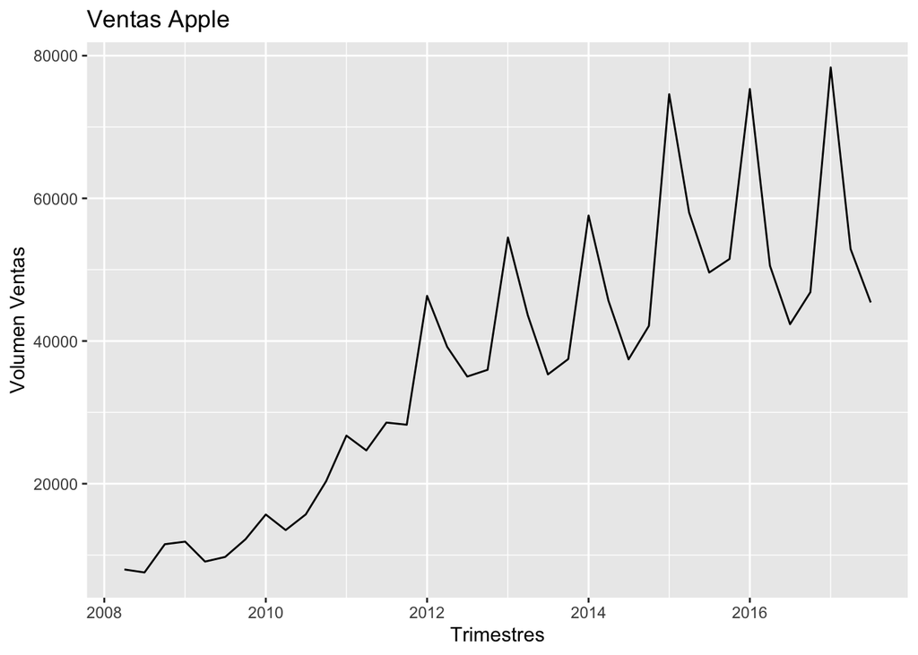

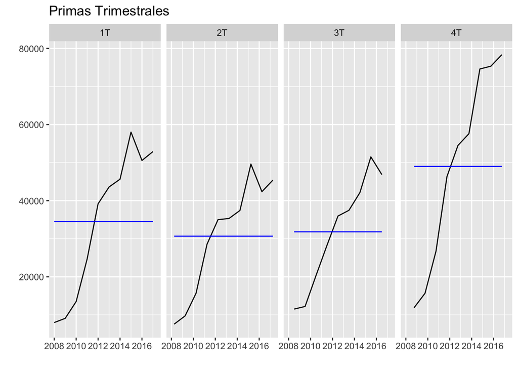

# Series temporales: Componentes

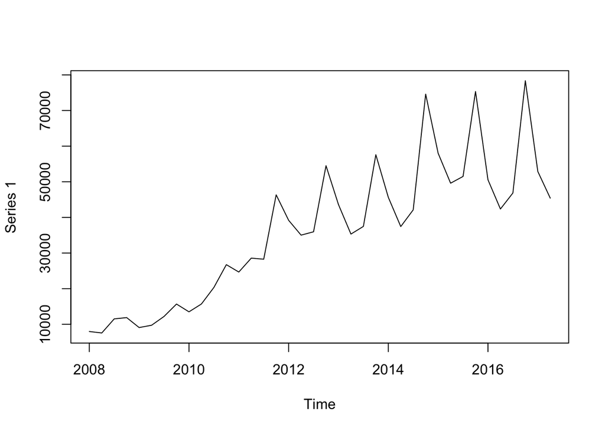

# Cálculo del Modelo de ETS

```
##
## Forecast method: ETS(M,A,N)
##
## Model Information:
## ETS(M,A,N)
##
## Call:
##  ets(y = xVentas)
##
##   Smoothing parameters:
##     alpha = 0.234
##     beta  = 1e-04
##
##   Initial states:
##     l = 6999.8793
##     b = 1326.6805
##
##   sigma:  0.2519
##
##      AIC     AICc      BIC
## 824.3466 826.2216 832.5346
##
## Error measures:
##                   ME  RMSE      MAE       MPE     MAPE      MASE        ACF1
## Training set 78.0778 10071 7319.563 -4.383509 18.84434 0.8057739 -0.01484917
##
## Forecasts:
##    Point Forecast    Lo 80    Hi 80    Lo 95     Hi 95
## 39       59489.08 40281.39 78696.76 30113.45  88864.70
## 40       60816.05 40639.91 80992.20 29959.30  91672.80
## 41       62143.03 41008.97 83277.09 29821.28  94464.78
## 42       63470.01 41386.62 85553.40 29696.38  97243.64
## 43       64796.98 41771.21 87822.76 29582.11 100011.86
## 44       66123.96 42161.40 90086.53 29476.38 102771.54
## 45       67450.94 42556.01 92345.87 29377.43 105524.45
## 46       68777.92 42954.05 94601.78 29283.72 108272.11
## 47       70104.89 43354.68 96855.11 29193.97 111015.82
## 48       71431.87 43757.14 99106.60 29107.02 113756.72
```

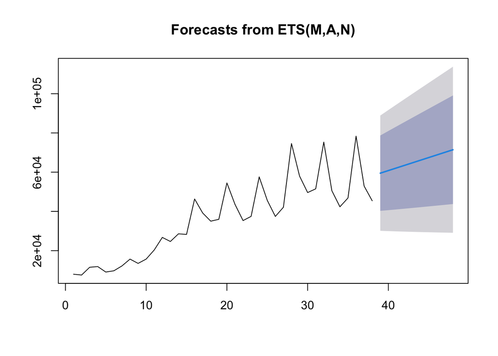

```
##           ME         RMSE          MAE          MPE         MAPE         ACF1
## -9937.360471 10259.914274  9937.360471   -20.733460    20.733460    -0.500000
##    Theil's U
##     1.667969
```

# **ARIMA**

ARIMA, es un algoritmo de pronóstico basado en la idea de que la información en los valores pasados de la serie temporal puede usarse por sí sola para predecir los valores futuros.

# Ventas Trimestrales Apple Modelo ARIMA

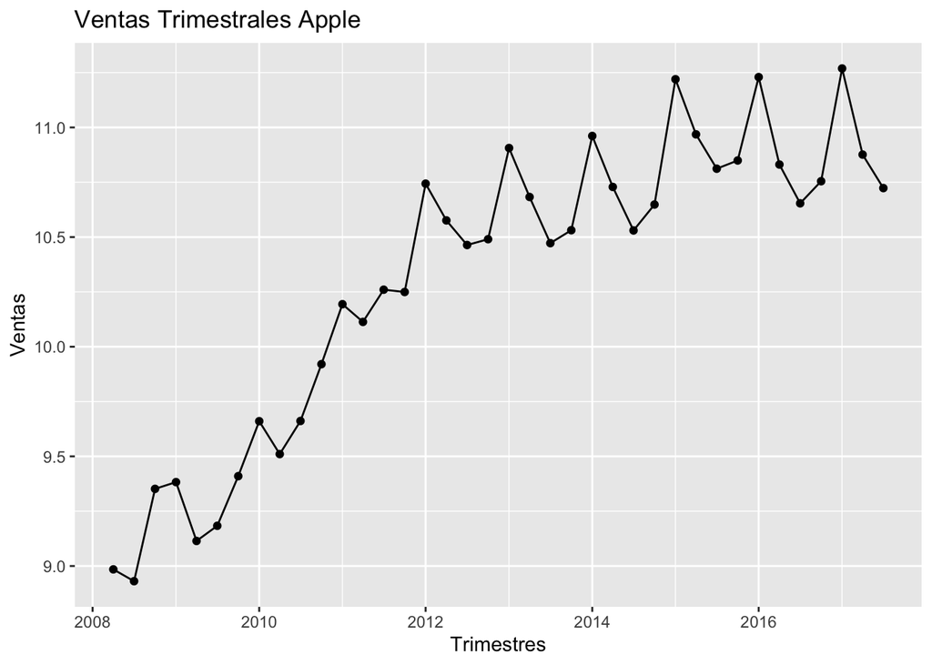

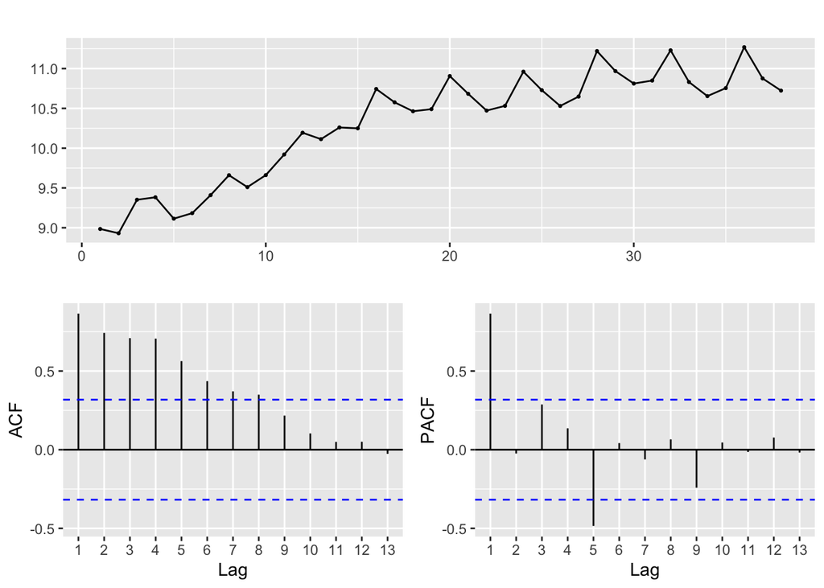

# Ventas Trimestrales LOG Apple

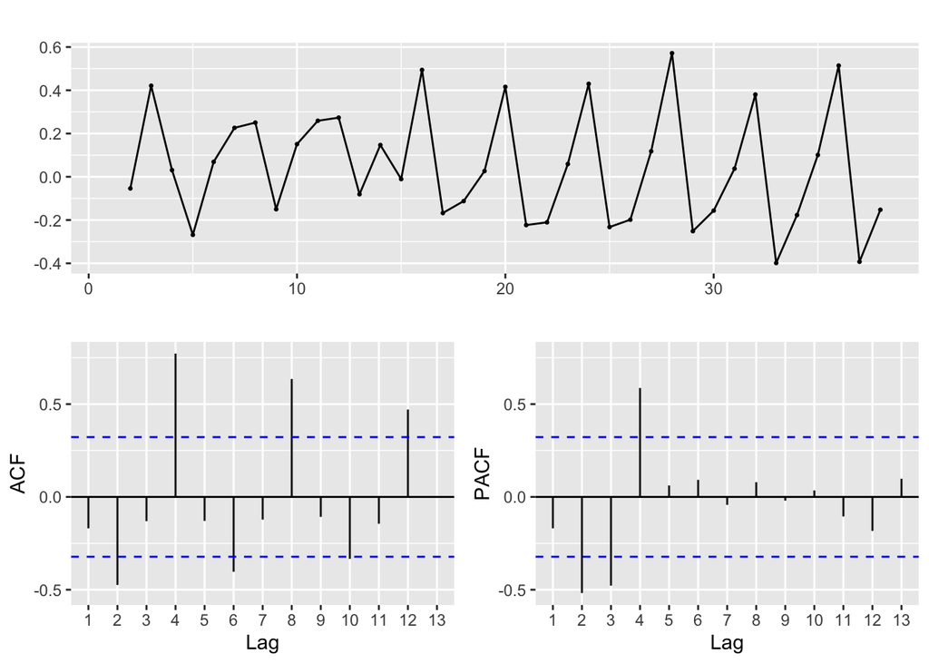

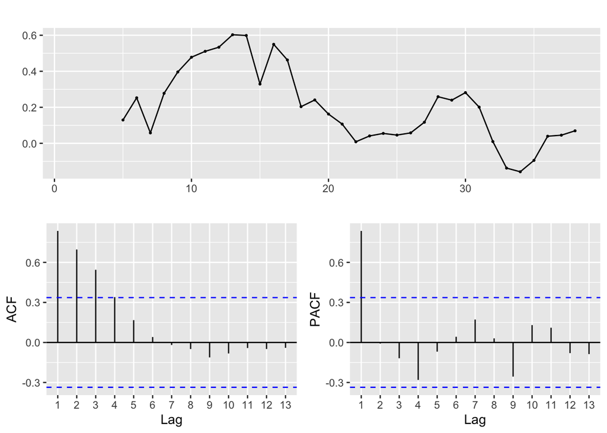

# Modelo ARIMA

```
## Series: xVentas
## ARIMA(0,1,1) with drift
## Box Cox transformation: lambda= 0
##
## Coefficients:
##           ma1   drift
##       -0.5580  0.0512
## s.e.   0.1247  0.0181
##
## sigma^2 estimated as 0.06073:  log likelihood=0.17
## AIC=5.67   AICc=6.4   BIC=10.5
##
## Training set error measures:
##                     ME     RMSE      MAE      MPE     MAPE      MASE
## Training set -693.1318 11036.29 8240.618 -2.53836 20.11484 0.9071682
##                     ACF1
## Training set -0.02906096
```

# **Conclusión**

La conclusión después del análisis ha sido que las ventas suben en el cuarto semestre, es decir, la gente tiende a comprar más en la época de invierno. Esta tendencia se repite cada año al ser este periodo de tiempo normalmente cuando hay nuevos lanzamientos en todos los dispositivos Apple.

Comparando los dos modelos, ETS y ARIMA, estudio de los modelos y los gráficos, he llegado a la conclusión que el mejor modelo es el ETS, porque se plantea con menos error.

# GitHub

Repositorio CP04: https://github.com/martaruedas/CP04_Apple.git